# Introducción al lenguaje R

Septiembre 2024

## 1. Introducción a R y RStudio.

## 1.1 ¿Qué es R y RStudio?

## ¿Qué es R?

- R: lenguje de programación para el análisis y la visualización de datos.
  - Creado por **Ross Ihaka** y **Robert Gentleman** a partir del lenguaje estadístico S.
  - Uso extendido en investigación, docencia e industria (Google, Facebook, Twitter, NYT, Pfizer, Santander, BBVA, Teléfonica, etc.).
- Características:
  - Almacenamiento y manipulación efectiva de datos.
  - Operadores para realizar cálculos sobre variables indexadas (arrays), en particular matrices.
  - Sentencias condicionales, ciclos, funciones recursivas y posibilidad de entradas y salidas.
  - Herramienta para el análisis de datos.
  - Multitud de opciones para el análisis gráfico.

## ¿Qué es RStudio?

- RStudio: entorno de progrmación.
  - Interprete de R que evalua expresiones (aritméticas, lógicas, llamadas a funciones o asignaciones).
  - Leer y escribir ficheros de datos.
  - Generar y guardar gráficos.
  - Crear scripts.
  - Crear ficheros de informes.

## 1.2 Ventajas e inconvenientes de R.

## Ventajas e inconvenientes de R.

| Ventajas | Inconvenientes |
| --- | --- |
| Herramienta de software libre, gratuito | Aprender a programar |
| Comunidad sólida con participantes del mundo académico y la industria | No intuitivo |
| Desarrollar funciones, paquetes o plantillas de documentos | Comprender lo que hace el código |
| Al día con las novedades estadísticas | Acostumbrarse a revisar el código y la salida |
| Creación y automatización de flujos de trabajo y análisis reproducibles | Algunas funciones novedosas necesitan más rodaje |

## 1.3 Trabajando con RStudio.

## Entrorno de programación RStudio.

[figure not shown]

## Consola

Es un interprete interactivo de comandos.

- Instrucciones: expresión (se evalua, se imprime, se pierde) o asignación (se evalua, se guarda).
- Solicitudes de ayuda, ejemplo: *help(solve)* o *?solve*.
- Llamadas a funciones
- Instrucciones que generen gráficas.
- Si produce salida -> debajo de la línea de código

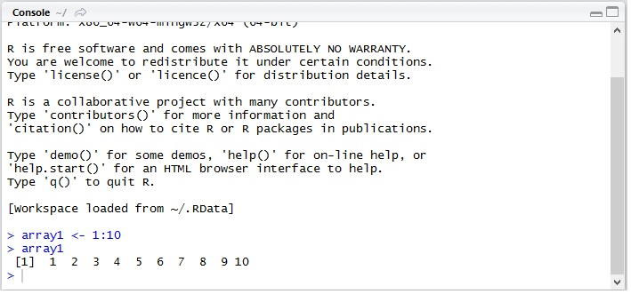

## Editor de texto

Diagnóstico de sintáxis:

- cruz roja (error sintáctico)
- exclamación amarilla (variable u objeto no utilizado o no declarado)
- círculo azul (ayuda)

[figure not shown]

## Panel de programación

Panel de programación: variables de entorno, el historial de comandos, el control de versiones, etc.

- *Enviroment*: contenido de los objetos
  - Los podemos guardar en un fichero .RData. -> recuperar los objetos de una sesión anterior
  - Conjunto de objetos almacenados en cada momento: *espacio de trabajo (workspace)*.

[figure not shown]

## Panel de programación

- *History*: Historial de comandos introducidos.
  - Todas las instrucciones de la línea de comandos se guardan aquí.
  - Guardar en un fichero .Rhistory.
  - Cargar un fichero .Rhistory.
  - *escoba* borrar todo el histórico de instrucciones.

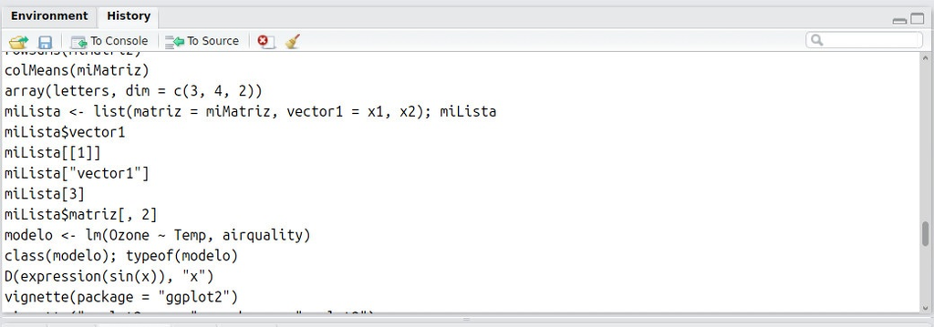

## Panel multifunción

Panel multifunción = navegador de archivos + carrusel de gráficas + gestor de paquetes + ayuda en línea + visualizador.

- *Files*: explorar archivos en nuestro ordenador.
- *Plots*: gráficos que vayamos construyendo (expotarlas, eliminarlas).
- *Packages*: paquetes que tenemos instalados.
  - *install* instalar nuevos paquetes.
- *Help*: muestra la ayuda solicitada mediante comando. Navegar a través de todos los topics de ayuda, imprimirlos, búsqueda de ayuda general.

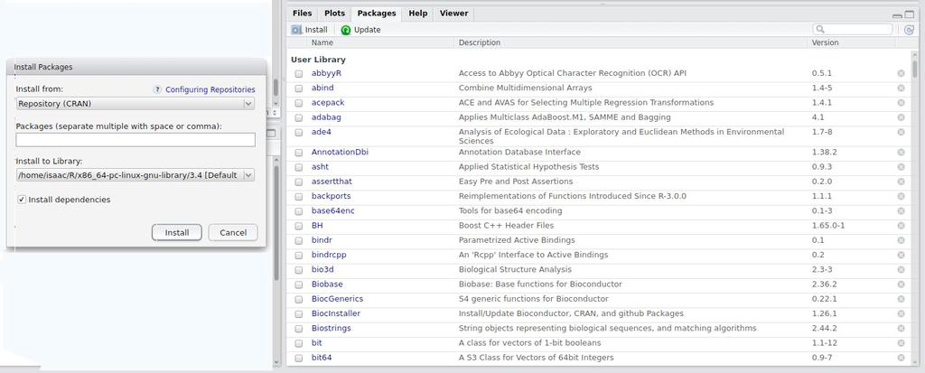

## 1.4 Como hacer proyectos en RStudio

## Directorio de trabajo

Directorio de trabajo: carpeta con scripts + paquetes + ficheros de datos de entrada + resultados + gráficas.

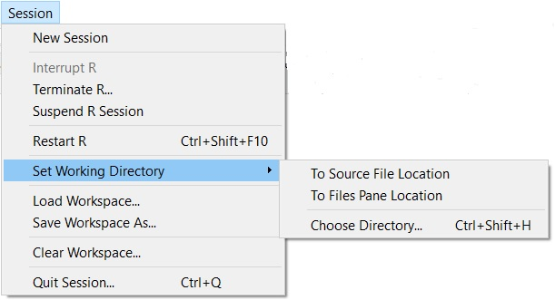

## Nuevo proyecto

1º. Menú *File* -> *New Porject*.

[figure not shown]

2º. Opción *New Directory*, seleccionams la opción *New Project*:

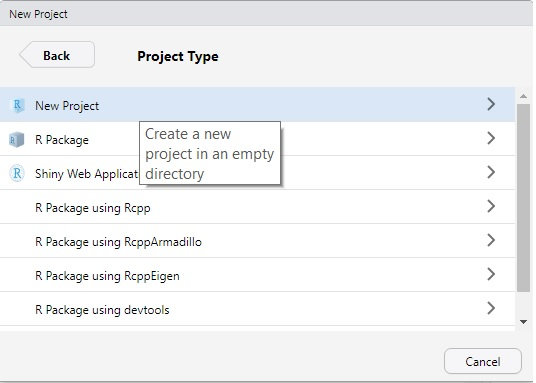

## Nuevo proyecto

3º. Nombre del proyecto y hacemos click en *Create Project*.

[figure not shown]

## 2. Programación científica en R

## 2.1 Tipos de datos

## Tipos de objetos

Los objetos o variables de R pueden almacenar:

- *valores numéricos*
- *valores alfabéticos* (cadenas de caracteres que van entre comillas dobles o comillas simples)
- *valores lógicos* (TRUE o FALSE)

```r
# Variable numérica:
a = 2

# Variable alfabética (cadena de caracteres):
cadena = "Caracteres"

# Variable lógica:
## TRUE  ## verdadero, también abreviado como T
## FALSE  ## falso, también abreviado como F
1==TRUE  ## TRUE está mapeado al valor entero 1L
```

```
## [1] TRUE
```

```r
0==FALSE  ## FALSE está mapeado al valor entero 0L
```

```
## [1] TRUE
```

## Tipos de objetos

Asignación de valores:

- Asignación: <-, =.
- Cualquier variable solo puede tener un *único valor* en cada instante.
- Se evalua la expresión de la derecha

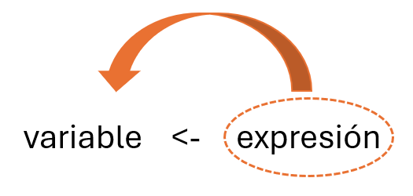

## Tipos de objetos

```r
# Variable numérica:
x <- 3.2
y = 2*x - 5
y
```

```
## [1] 1.4
```

```r
y = 10.0
y
```

```
## [1] 10
```

```r
#Variable alfabética
nom = "Juan"
nom
```

```
## [1] "Juan"
```

## Tipos de objetos

```r
# Lista de los objetos creados:
ls()
```

```
## [1] "a"      "cadena" "nom"    "x"      "y"
```

```r
# Borrado de objetos:
rm(x)
ls()
```

```
## [1] "a"      "cadena" "nom"    "y"
```

## Operadores aritméticos

- Operadores aritméticos: +, -, *, / y ^.
  - funciones log, exp, sin, cos, tan y sqrt.

```r
var1 <- 1.2
var2 = 0.25
var3 = 3*sin(var2)+23.57
var3
```

```
## [1] 24.31221
```

```r
z = 3
i = (z*2+75)/2
i
```

```
## [1] 40.5
```

## Operadores lógicos

- Operadores lógicos: <, <=, >, >=, ==, y !=.
- Siendo v1 y v2 variables lógicas
  - v1&v2: conjunción
  - v1|v2: disyunción
  - !v1: negación de V1

```r
a <- 2>3
a
```

```
## [1] FALSE
```

```r
b <- 5<10
c <- a&b
c
```

```
## [1] FALSE
```

## 2.2 Funciones

## Funciones: definición

- Tipo de objeto de R
  - Conjunto de líneas de código que definen una tarea
  - Se pueden utilizar en cualquier punto del programa
- Existen funciones que podemos utilizar: `nombre_func(arg1, arg2...)`.

```r
# Esta instrucción devuelve el máximo de todos los números que se le han pasado por argumento
max(4,5,6,12,-4)
```

```
## [1] 12
```

```r
# Media de una secuencia de 30 elementos elegidos al azar de entre el 1 y el 100.
mean(sample(1:100, 30))
```

```
## [1] 49.83333
```

## Funciones: creación

- Creación de funciones propias:
  - Cuerpo delimitado por {}
  - Instrucción por línea
  - Indicar valores por defecto de argumentos (en caso de tenerlos)

```r
#Función que convierte un valor en km, decímetros, centímetros o milímetros a metros.
convUnitsToMeters = function(val, from="km"){
  #La función switch de R compara el contenido de una variable con  un conjunto de opciones.
  mult = switch(from,km=1000,dm=0.1,cm=0.01,mm=0.001,NA)
  if (is.na(mult)) stop("Unknown target unit of lenght")
  else return (val*mult)
}
convUnitsToMeters(23,"km")
```

```
## [1] 23000
```

```r
convUnitsToMeters(from = "cm", val = 40)
```

```
## [1] 0.4
```

## Funciones: creación

Llamada a una función:

- Indicando el nombre de los parámetros. Ventaja: omitir el nombre de parámetros que tengan valor por defecto y no queramos modificar.

```r
convUnitsToMeters(val=56.2)
```

```
## [1] 56200
```

- Sin indicar el nombre de los parámetros. Es necesario respetar la posición.

```r
convUnitsToMeters(56.2,"km")
```

```
## [1] 56200
```

- Mezcla de las anteriores

```r
convUnitsToMeters(56.2, from="km")
```

```
## [1] 56200
```

## 2.3 Vectores.

## Vectores: definición

- Objeto básico de R.
- Estructura de datos **homogénea** en la que los valores almacenados ocupan una determinada posición.
- Creación de vector mediante operador “:”

```r
1:20
```

```
##  [1]  1  2  3  4  5  6  7  8  9 10 11 12 13 14 15 16 17 18 19 20
```

```r
10:15 - 1
```

```
## [1]  9 10 11 12 13 14
```

## Vectores: creación

- Creación de vector mediante función c():

```r
v1 = c(10, 20, 30)  # elementos que va contener el vector
v1
```

```
## [1] 10 20 30
```

```r
v2 = c("jamón", "jabugo", "5J")
v2
```

```
## [1] "jamón"  "jabugo" "5J"
```

```r
# Tamaño del vector
length(v1)
```

```
## [1] 3
```

## Vectores: creación

- Creación de vector mediante función c():

```r
# Homogeneo????
v = c(5, 2, 53.85, 43.2, 30, "abd")
#Todos los elementos del vector se han convertido a tipo string (lo comprobamos).
v
```

```
## [1] "5"     "2"     "53.85" "43.2"  "30"    "abd"
```

```r
mode(v)
```

```
## [1] "character"
```

```r
length(v)
```

```
## [1] 6
```

## Vectores: creación

- Creación de vector mediante función `seq()`:

```r
x = seq(-3, 3, by=.5) #inicio, fin, salto
x
```

```
##  [1] -3.0 -2.5 -2.0 -1.5 -1.0 -0.5  0.0  0.5  1.0  1.5  2.0  2.5  3.0
```

```r
# Al especificar que solo queremos 4 elementos, calcula él el salto
seq(from = 1, to = 5, length = 4)
```

```
## [1] 1.000000 2.333333 3.666667 5.000000
```

```r
# Ahora le especificamos el tamaño, el inicio y el salto, por lo que calcula automáticamente
# cual será el fin
seq(length = 10, from = -2, by = 0.2)
```

```
##  [1] -2.0 -1.8 -1.6 -1.4 -1.2 -1.0 -0.8 -0.6 -0.4 -0.2
```

## Vectores: creación

- Creación de vector mediante repetición de secuencia o secuencias aleatorias:

```r
rep(5, 4)
```

```
## [1] 5 5 5 5
```

```r
rep(1:2, each = 3)
```

```
## [1] 1 1 1 2 2 2
```

```r
# Secuencias aleatorias:
rnorm(4, mean=10, sd=3)
```

```
## [1]  4.610373  9.812542  8.441047 12.410862
```

## Vectores: creación

- Creación de vector vacío:

```r
x = vector()
x
```

```
## logical(0)
```

```r
x[1]
```

```
## [1] NA
```

## Vectores: indexación

- Acceso a determinados elementos de un vector
- `NA`: dato faltante. Las operaciones no se pueden realizar, pero no da error.

```r
vl = c(FALSE, TRUE, NA, TRUE, TRUE)
vl
```

```
## [1] FALSE  TRUE    NA  TRUE  TRUE
```

```r
# Elementos que se encuentra entre la posición 1 y 3
vl[1:3]
```

```
## [1] FALSE  TRUE    NA
```

```r
# OJO: en R, el acceder a una posición que NO existe no genera ningún error
vl[7]
```

```
## [1] NA
```

## Vectores: indexación

- Indexación mediante **máscara**.

```r
x = c(0, -3, 4, -1, 45, 90, -5)
x[x>0]
```

```
## [1]  4 45 90
```

```r
x[x<=-2 | x>5]
```

```
## [1] -3 45 90 -5
```

```r
x[x>40 & x<100]
```

```
## [1] 45 90
```

## Vectores: modificación del tamaño

```r
# x es un vector con elementos de -3.0 a 3.0 con salto de 0.5
x = seq(-3, 3, by=.5)
x
```

```
##  [1] -3.0 -2.5 -2.0 -1.5 -1.0 -0.5  0.0  0.5  1.0  1.5  2.0  2.5  3.0
```

```r
length(x)
```

```
## [1] 13
```

```r
# Añadimos el elemento 28 en la posición 15:
x[15] = 28
# Como en la posición 14 no tenía nada, se ha añadido un NA, hasta llegar a la nueva posición
x
```

```
##  [1] -3.0 -2.5 -2.0 -1.5 -1.0 -0.5  0.0  0.5  1.0  1.5  2.0  2.5  3.0   NA 28.0
```

## Vectores: operaciones vectorizadas

- Las operaciones sobre vectores se realizan elemento a elemento.

```r
v1 = c(1, 3, 5)
v2 = c(18, 9, 28)
v1+v2
```

```
## [1] 19 12 33
```

```r
# OJO: el tamaño no coincide
v1 = c(1, 3, 5, 7)
# Es como si v2 fuera (10, 2, 10, 2)
v2 = c(10, 2)
v1 + v2
```

```
## [1] 11  5 15  9
```

## Vectores: operaciones vectorizadas

```r
# Si el tamaño no es un múltiplo, sale un warning
v2 = c(10, 2, 4)
v1 + v2
```

```
## [1] 11  5  9 17
```

## 2.4 Control de flujo.

## Sentencias condicionales

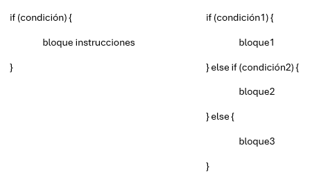

## Bucles

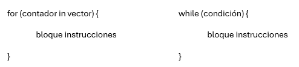

## Vectorizar

- Bucles `for` son muy lentos
- Funciones de R vectorizadas
- Mejor solución: vectorizar

```r
n=100000
x=1:n
tiempo1=system.time({y1=integer(n)
             for (i in 1:n) y1[i]=x[i]^2
             })
tiempo1
```

```
##    user  system elapsed
##    0.00    0.00    0.02
```

```r
tiempo2=system.time({y2=x^2})
tiempo2
```

```
##    user  system elapsed
##       0       0       0
```

## Familia `apply()`

- Aplicar una función a todos los elementos de un objeto
- `apply(matrix, i, fun)`
  - Si `i=1`: aplica `fun` a todas las filas de `matrix`
  - Si `i=2`: aplica `fun` a todas las columnas de `matrix`
- `lapply(lista, fun)`

```r
A = matrix(runif(50),nrow=10)
sumCuadrados=function(x){sum(x^2)}  # Función que calcula la suma de cuadrados de
                                    # los términos de un vector x
apply(A,1,sumCuadrados)  # Devuelve la suma de cuadrados de cada fila de A
```

```
##  [1] 1.441582 1.892691 2.445929 1.386603 2.407547 2.767028 1.541693 1.363664
##  [9] 1.152924 1.814343
```

## 2.5 Factores.

## Factores: definición

- Manejo de valores categóricos.

```r
cats = c(rep("malo", 2), rep("regular", 2),
         rep("bueno", 3) )
fcats = factor(cats)
fcats
```

```
## [1] malo    malo    regular regular bueno   bueno   bueno
## Levels: bueno malo regular
```

```r
as.numeric(fcats)  ## Código numérico para cada categoría
```

```
## [1] 2 2 3 3 1 1 1
```

```r
levels(fcats)  ## Niveles de categorías reconocidos
```

```
## [1] "bueno"   "malo"    "regular"
```

## Factores

- Por defecto, R trata los factores como si fuesen variables *nominales*, no *ordinales*.

```r
## Establecer explicitamente un orden de los niveles
ofcats = factor(cats, labels = c("malo", "regular", "bueno"),
                ordered = TRUE)
ofcats
```

```
## [1] regular regular bueno   bueno   malo    malo    malo
## Levels: malo < regular < bueno
```

## Factores

- Con una variable de tipo factor se pueden contar las ocurrencias de cada posible valor.

```r
fgenero = factor(c("m", "f", "m", "m", "m"), levels = c("f","m"))
table(fgenero)
```

```
## fgenero
## f m
## 1 4
```

```r
a = factor(c("adult", "adult", "juvenil", "juvenil", "adult"))
# Se pueden cruzar dos factores
t = table(a,fgenero)
t
```

```
##          fgenero
## a         f m
##   adult   1 2
##   juvenil 0 2
```

## Factores

- Función **gl()**: generación de factores a partir de secuencias.

```r
# gl(número de niveles, número de repeticiones)
gl(3, 5)
```

```
##  [1] 1 1 1 1 1 2 2 2 2 2 3 3 3 3 3
## Levels: 1 2 3
```

```r
gl(2, 5, labels = c("female", "male"))
```

```
##  [1] female female female female female male   male   male   male   male
## Levels: female male
```

## 2.6 Matrices y Arrays

## Matrices: definición y creación

- **Array**: vector de varias dimensiones.
  - **Matriz**: array de 2 dimensiones
- Estructura **homogénea** de almacenamiento.

```r
# Vector
m = c(45, 23, 66, 77, 33, 44, 56, 12, 78, 23)
m
```

```
##  [1] 45 23 66 77 33 44 56 12 78 23
```

```r
# El contenido del vector se reparte a través de la matriz con 2 filas y 5 columnas.
dim(m) = c(2, 5)
m
```

```
##      [,1] [,2] [,3] [,4] [,5]
## [1,]   45   66   33   56   78
## [2,]   23   77   44   12   23
```

## Matrices: creación

- Construcción de una matriz mediante la función `matrix(contenido de la matriz en forma de vector, número de filas, número de columnas)`.

```r
# La matriz se va rellenando por columnas
m = matrix(c(45, 23, 66, 77, 33, 44, 56, 12, 78, 23), 2, 5)
m
```

```
##      [,1] [,2] [,3] [,4] [,5]
## [1,]   45   66   33   56   78
## [2,]   23   77   44   12   23
```

```r
# Si queremos que la matriz se vaya rellenando por filas, debemos utilizar el argumento byrow
m = matrix(c(45, 23, 66, 77, 33, 44, 56, 12, 78, 23), 2, 5, byrow = TRUE)
m
```

```
##      [,1] [,2] [,3] [,4] [,5]
## [1,]   45   23   66   77   33
## [2,]   44   56   12   78   23
```

## Arrays: creación

- Creación de un array multidimensional mediante la función `array()`.
- Hay que indicarle el contenido del array y la dimensión.

```r
# Array de dimensión 4x3x2
a = array(5:29, dim=c(4, 3, 2))
a
```

```
## , , 1
##
##      [,1] [,2] [,3]
## [1,]    5    9   13
## [2,]    6   10   14
## [3,]    7   11   15
## [4,]    8   12   16
##
## , , 2
##
##      [,1] [,2] [,3]
## [1,]   17   21   25
## [2,]   18   22   26
## [3,]   19   23   27
## [4,]   20   24   28
```

## Matrices y Arrays: nombre de columnas y filas

- Función `colnames()`: darle nombre a las columnas de una matriz
- Función `rownames()`: darle nombre a las filas de una matriz.

```r
results = matrix(c(10, 20, 30, 40, 21, 32, 43, 13), 2, 4, byrow = TRUE)
colnames(results) = c("1qrt", "2qrt", "3qrt", "4qrt")
rownames(results) = c("store1", "store2")
results
```

```
##        1qrt 2qrt 3qrt 4qrt
## store1   10   20   30   40
## store2   21   32   43   13
```

## Matrices y Arrays: indexación

- Se puede acceder a los elementos de una matriz igual que se puede acceder a los elementos de un vector.

```r
m[1, ] # elementos de una fila
```

```
## [1] 45 23 66 77 33
```

```r
m[, 4] # elementos de una columna
```

```
## [1] 77 78
```

```r
m[1, -c(3, 5)] # elementos de una fila menos los que están en ciertas columnas
```

```
## [1] 45 23 77
```

```r
m[-2, 1]# Elemetos de una columna menos los que están en una determinada fila
```

```
## [1] 45
```

## Matrices y Arrays: indexación

- La indexación en arrays es igual que en las matrices.

```r
a[1, 3, 2]
```

```
## [1] 25
```

```r
a[1, , 2]
```

```
## [1] 17 21 25
```

```r
a[4, 3, ]
```

```
## [1] 16 28
```

```r
a[c(2, 3), , -2] # elementos de las filas 2 y 3, todas las columnas, solo los que están en la primera tabla
```

```
##      [,1] [,2] [,3]
## [1,]    6   10   14
## [2,]    7   11   15
```

## Matrices y Arrays: indexación

- Se puede indexar por nombre.

```r
results["store1", ]
```

```
## 1qrt 2qrt 3qrt 4qrt
##   10   20   30   40
```

```r
results["store2", c("1qrt", "4qrt")]
```

```
## 1qrt 4qrt
##   21   13
```

## Matrices y Arrays: añadir

- Función `cbind()`: unir columnas a una matriz o array.
- Función `rbind()`: unir filas a una matriz o array.

```r
m1 = matrix(c(45, 23, 66, 77, 33, 44, 56, 12, 78, 23), 2, 5)
m1
```

```
##      [,1] [,2] [,3] [,4] [,5]
## [1,]   45   66   33   56   78
## [2,]   23   77   44   12   23
```

```r
# Añadimos el vector (4 ,76) a la 4º columna de m1
m2 = cbind(c(4, 76), m1[, 4])
m2
```

```
##      [,1] [,2]
## [1,]    4   56
## [2,]   76   12
```

## Matrices y Arrays: añadir

```r
# Añadimos al final
m3 = cbind(m1, c(4, 76))
m3
```

```
##      [,1] [,2] [,3] [,4] [,5] [,6]
## [1,]   45   66   33   56   78    4
## [2,]   23   77   44   12   23   76
```

```r
#Añadimos en una posición concreta
m4 = cbind(m1, c(4, 76))[, c(1, 2, 6, 3, 4, 5)]
m4
```

```
##      [,1] [,2] [,3] [,4] [,5] [,6]
## [1,]   45   66    4   33   56   78
## [2,]   23   77   76   44   12   23
```

## Matrices y Arrays: añadir

```r
# Definimos una nueva matriz
m4 = matrix(rep(12, 20), 4, 5)
m4
```

```
##      [,1] [,2] [,3] [,4] [,5]
## [1,]   12   12   12   12   12
## [2,]   12   12   12   12   12
## [3,]   12   12   12   12   12
## [4,]   12   12   12   12   12
```

```r
# Creamos una matriz a partir de la unión de la fila 1 de m1 y la fila 3 de m4
m5 = rbind(m1[1, ], m4[3, ])
m5
```

```
##      [,1] [,2] [,3] [,4] [,5]
## [1,]   45   66   33   56   78
## [2,]   12   12   12   12   12
```

## Matrices y Arrays: operaciones artiméticas

- Al igual que en los vectores, estas operaciones están vectorizadas.

```r
m1 = matrix(c(45, 23, 66, 77, 33, 44), 2, 3)
m1
```

```
##      [,1] [,2] [,3]
## [1,]   45   66   33
## [2,]   23   77   44
```

```r
m2 = matrix(c(12, 65, 32, 7, 4, 78), 2, 3)
m2
```

```
##      [,1] [,2] [,3]
## [1,]   12   32    4
## [2,]   65    7   78
```

```r
m1 + m2
```

```
##      [,1] [,2] [,3]
## [1,]   57   98   37
## [2,]   88   84  122
```

## Matrices y Arrays: operaciones aritméticas

```r
m1 - m2
```

```
##      [,1] [,2] [,3]
## [1,]   33   34   29
## [2,]  -42   70  -34
```

```r
2*m1
```

```
##      [,1] [,2] [,3]
## [1,]   90  132   66
## [2,]   46  154   88
```

## 2.7 Listas

## Listas: definición y construcción

- Colección **heterogénea** y **ordenada** de elementos:
  - Permiten crear **agrupaciones de elementos de distinto tipo**.
  - Cada elemento de una lista puede ser un tipo de dato individual: un vector, una matriz, etc.

```r
l1 = list(primero=c(1,2,3,4),
          segundo="hola",
          tercero=matrix(c(1,2,3,4), nrow = 2))
l1
```

```
## $primero
## [1] 1 2 3 4
##
## $segundo
## [1] "hola"
##
## $tercero
##      [,1] [,2]
## [1,]    1    3
## [2,]    2    4
```

## Listas: definición y construcción

Dar nombre a los elementos después de crear la lista.

```r
my.lst2 = list(12584, "Marcos", c(8.5, 10, 17,9.75))
names(my.lst2) = c("id", "name", "marks")
my.lst2
```

```
## $id
## [1] 12584
##
## $name
## [1] "Marcos"
##
## $marks
## [1]  8.50 10.00 17.00  9.75
```

## Listas: definición y construcción

- Función **unlist()**: transforma una lista en un vector -> cambios en los tipos de elementos (cadenas de caracteres).

```r
unlist(my.lst2)
```

```
##       id     name   marks1   marks2   marks3   marks4
##  "12584" "Marcos"    "8.5"     "10"     "17"   "9.75"
```

## Listas: indexación

Mediante el nombre de los elementos o mediante la posición que ocupan.

```r
l1$primero # equivalente a: l1[[1]]
```

```
## [1] 1 2 3 4
```

```r
l1$primero[1]
```

```
## [1] 1
```

```r
# Elemento que se encuentra en la 3º posición
l1[[3]] # Si no ponemos corchetes, obtenemos una sublista de la lista original
```

```
##      [,1] [,2]
## [1,]    1    3
## [2,]    2    4
```

```r
## ¿Cómo obtenemos el elemento [2,2] de la matriz en tercer lugar de la lista?
l1[[3]][2,2]
```

```
## [1] 4
```

```r
l1$tercer[2,2]
```

```
## [1] 4
```

## Listas: modificación

Añadir o quitar elementos a una lista.

```r
# Añadimos un elemento
l1$cuarto = c("Ana", "Miguel", "Juan")
l1
```

```
## $primero
## [1] 1 2 3 4
##
## $segundo
## [1] "hola"
##
## $tercero
##      [,1] [,2]
## [1,]    1    3
## [2,]    2    4
##
## $cuarto
## [1] "Ana"    "Miguel" "Juan"
```

## Listas: modificación

```r
# Quitamos un elemento
l1 <- l1[-2]
l1
```

```
## $primero
## [1] 1 2 3 4
##
## $tercero
##      [,1] [,2]
## [1,]    1    3
## [2,]    2    4
##
## $cuarto
## [1] "Ana"    "Miguel" "Juan"
```

La importancia de las listas radica en que muchos de los tipos complejos de R se derivan de listas.

## 2.8 Data Frames: datos estructurados en R

## Datos estructurados y no estructurados

- **Datos estructurados**: se pueden organizar aplicando un esquema previo (estructura), que es conocido antes de realizar su análisis y se mantiene fijo.
  - Ejemplo: una tabla de una base de datos relacional, un archivo CSV.
- **Datos no estructurados**: no se puede organizar a priori, puesto que pueden contener cualquier tipo de información en cualquier formato.
- `data.frame`:
  - Tipo o estructura de datos que permite almacenar datos estructurados, semejante a una tabla en una base de datos.
  - Esperamos tener las variables por columnas y los casos (sujetos, elementos) en las filas.
  - **Se ha replicado exactamente** en otros lenguajes y entornos.
    - En Python (librería `Pandas`) o en Spark (`DataFrames` y derivados).

## Data Frames: creación

```r
## A partir de una lista
lista2 = list(A=c(1,2,3,4),
              B=c(0.1, 0.2, 0.1, 0.2),
              Group=c("M", "M", "F", "F"))
df1 = as.data.frame(lista2)
df1
```

```
##   A   B Group
## 1 1 0.1     M
## 2 2 0.2     M
## 3 3 0.1     F
## 4 4 0.2     F
```

## Data Frames: características

```r
# Número de filas
nrow(df1)
```

```
## [1] 4
```

```r
# Número de columnas
ncol(df1)
```

```
## [1] 3
```

```r
# Dimensión
dim(df1)
```

```
## [1] 4 3
```

## Data Frames: características

```r
names(df1)
```

```
## [1] "A"     "B"     "Group"
```

```r
# Podemos cambiar el nombre de las columnas de un Data Frame
names(df1)=c("col1","col2","col3")
df1
```

```
##   col1 col2 col3
## 1    1  0.1    M
## 2    2  0.2    M
## 3    3  0.1    F
## 4    4  0.2    F
```

## Data Frames: inspección de contenido

```r
## CO2 es uno de los numerosos Data Frame precargados en R
## ?CO2
head(CO2)  ## Muestra las 6 primeras filas
```

```
##   Plant   Type  Treatment conc uptake
## 1   Qn1 Quebec nonchilled   95   16.0
## 2   Qn1 Quebec nonchilled  175   30.4
## 3   Qn1 Quebec nonchilled  250   34.8
## 4   Qn1 Quebec nonchilled  350   37.2
## 5   Qn1 Quebec nonchilled  500   35.3
## 6   Qn1 Quebec nonchilled  675   39.2
```

```r
tail(CO2)  ## Muestra las 6 últimas filas
```

```
##    Plant        Type Treatment conc uptake
## 79   Mc3 Mississippi   chilled  175   18.0
## 80   Mc3 Mississippi   chilled  250   17.9
## 81   Mc3 Mississippi   chilled  350   17.9
## 82   Mc3 Mississippi   chilled  500   17.9
## 83   Mc3 Mississippi   chilled  675   18.9
## 84   Mc3 Mississippi   chilled 1000   19.9
```

## Data Frames: indexación

- Igual que la indexación de matrices: por posición o por nombre

```r
## Nominal (mediante nombre)
df1$col3
```

```
## [1] "M" "M" "F" "F"
```

```r
## Índice numérico (como una lista)
df1[[2]]
```

```
## [1] 0.1 0.2 0.1 0.2
```

## Data Frames: indexación

También se pueden utilizar **máscaras**.

```r
## Imponemos condición booleana en indexación
## ¡Cuidado, la coma al final es importante!
## Con esa coma seleccionamos todas las columnas
df1[df1$col2 < 0.2,]
```

```
##   col1 col2 col3
## 1    1  0.1    M
## 3    3  0.1    F
```

```r
## Una columna en concreto
df1[df1$col2 < 0.2, 3]
```

```
## [1] "M" "F"
```

## Data Frames: añadir columnas

```r
df1$Nota = c(4.5, 5.6, 6.1, 6.7)
df1
```

```
##   col1 col2 col3 Nota
## 1    1  0.1    M  4.5
## 2    2  0.2    M  5.6
## 3    3  0.1    F  6.1
## 4    4  0.2    F  6.7
```

## Data Frames: agrupando valores

```r
lista2 = list(A=c(1,2,3,4),
              B=c(0.1, 0.2, 0.1, 0.2),
              Group=c("M", "M", "F", "F"))
df1 = as.data.frame(lista2)
df1
```

```
##   A   B Group
## 1 1 0.1     M
## 2 2 0.2     M
## 3 3 0.1     F
## 4 4 0.2     F
```

## Data Frames: agrupando valores

```r
grupos = split(df1, df1$Group)
class(grupos)
```

```
## [1] "list"
```

```r
grupos
```

```
## $F
##   A   B Group
## 3 3 0.1     F
## 4 4 0.2     F
##
## $M
##   A   B Group
## 1 1 0.1     M
## 2 2 0.2     M
```

## 2.9 Fechas

## Fechas

- Paquete `lubridate` -> `library(tidyverse)`
- Objetos:
  - Dia `<date>`
  - Tiempo `<time>`
  - Dia-tiempo `<dttm>`
- **ISO8601**: año-mes-día horas:minutos:segundos

```r
today()
```

```
## [1] "2024-10-03"
```

```r
now()
```

```
## [1] "2024-10-03 07:59:56 CEST"
```

## 2.10 Importación y exportación de datos

## Importar datos

Importación de datos desde fuentes externas:

- Función `read.table()`. Contenido del fichero:
  - 1º fila = nombres de las variables.
  - cada fila = etiqueta fila + valores variables.

```r
data_economist <- read.table(file = "data/EconomistData.csv",
                    header = TRUE,
                    sep = ",")
head(data_economist)
```

```
##   X     Country HDI.Rank   HDI CPI            Region
## 1 1 Afghanistan      172 0.398 1.5      Asia Pacific
## 2 2     Albania       70 0.739 3.1 East EU Cemt Asia
## 3 3     Algeria       96 0.698 2.9              MENA
## 4 4      Angola      148 0.486 2.0               SSA
## 5 5   Argentina       45 0.797 3.0          Americas
## 6 6     Armenia       86 0.716 2.6 East EU Cemt Asia
```

## Importar datos

- Otras funciones: `readxl::read_excel()`

```r
data_rrhh <- readxl::read_excel("data/RRHH.xlsx")
data_rrhh
```

```
## # A tibble: 100 × 10
##    nivel_satisfaccion ultima_evaluacion numero_proyectos promedio_horas_mensua…¹
##                 <dbl>             <dbl>            <dbl>                   <dbl>
##  1               0.22              0.98                4                     185
##  2               0.89              0.65                5                     195
##  3               0.63              0.76                4                     245
##  4               0.8               0.96                3                     161
##  5               0.42              0.48                2                     155
##  6               0.77              0.82                4                     217
##  7               0.51              0.5                 5                     176
##  8               0.15              0.75                3                     259
##  9               0.98              0.99                3                     235
## 10               0.19              1                   4                     192
## # ℹ 90 more rows
## # ℹ abbreviated name: ¹promedio_horas_mensuales
## # ℹ 6 more variables: antiguedad <dbl>, accidente <chr>, abandona <chr>,
## #   promocionado <chr>, departamento <chr>, salario <chr>
```

## Importar datos

- Otras funciones: `read.csv()`

```r
data_students <- read.csv("data/students.csv")
data_students
```

```
##   Student.ID        Full.Name     favourite.food            mealPlan  AGE
## 1          1   Sunil Huffmann Strawberry yoghurt          Lunch only    4
## 2          2     Barclay Lynn       French fries          Lunch only    5
## 3          3    Jayendra Lyne                N/A Breakfast and lunch    7
## 4          4     Leon Rossini          Anchovies          Lunch only
## 5          5 Chidiegwu Dunkel              Pizza Breakfast and lunch five
## 6          6    Güvenç Attila          Ice cream          Lunch only    6
```

## Exportar datos

- Función `write.table()`
- Función `openxlsx::write.xlsx()`: exportar en excel
- Función `write.csv()`: exportar texto

```r
openxlsx::write.xlsx(x = lista2,
                     file = "data/lista2_excel.xlsx")
write.csv(x = lista2, file = "data/lista2_csv.csv")
```

## 2.11 Tidy data

## Principio de tidy Data

- Creador: **Hadley Wickham**, 2014
  - Establece los fundamentos de tidy data (estandar para el trabajo con datos estructurados en R).
  - Paquetes: ggplot2, dplyr y tidyr, devtools…
- **Tidyverse**: conjunto de paquetes de R que giran en torno a la premisa tidy data.
  - `dplyr`: procesado de datos estructurados de forma organizada y con fuen rendimiento.
  - `magrittr`: operador pipe (%>%)
  - `tidyr`: paquete principal que implementa los fundamentos de tidy data.

## Principios de tidy data: reglas básicas

1. Cada **variable** está en **una columna**.
2. Cada **observación** está en **una fila**.
3. Cada **valor** está en **una celda**.

(Basado en la filosofía de la tercera forma normal en bases de datos (Codd, 1990))

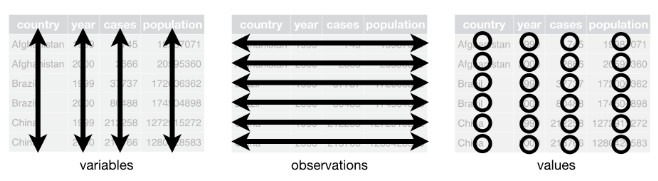

*Messy data*: los que no se ajustan.

## Principios de tidy data: reglas básicas

Ejemplo de un conjunto de datos típico.

| name | treatment_a | treatment_b |
| --- | --- | --- |
| John Smith | — | 2 |
| Jane Doe | 16 | 11 |
| Mary Johnson | 3 | 1 |

En formato *tidy data*.

| name | treatment | result |
| --- | --- | --- |
| John Smith | a | — |
| Jane Doe | a | 16 |
| Mary Johnson | a | 3 |
| John Smith | b | 2 |
| Jane Doe | b | 11 |
| Mary Johnson | b | 1 |

- Variables *categóricas* -> fila nueva por cada observación para cada nivel registrado de la variable
  - No hay pérdida de eficiencia: manejo interno mediante números enteros

## Principios de tidy data: ventajas

- Forma consistente de almacenar los datos -> uniformidad en las funciones.
- Tener las variables en columnas favorece la capacidad de vectorización de R.
- `dplyr`, `ggplot2` y todos los paquetes de `tidyverse` están diseñados para trabajar con tidy data.

## Principios de tidy data: ordenar datos

- Funciones para pivotar datos: `pivot_longer()` y `pivot_wider()`.

```r
df <- tribble(
  ~name,  ~treatment_a, ~treatment_b,
   "Johm Smith", NA ,  2,
   "Jane Doe",  16,  11,
   "Mary Johnson",  3,  1
)
df
```

```
## # A tibble: 3 × 3
##   name         treatment_a treatment_b
##   <chr>              <dbl>       <dbl>
## 1 Johm Smith            NA           2
## 2 Jane Doe              16          11
## 3 Mary Johnson           3           1
```

## Principios de tidy data: ordenar datos

```r
# Los NA en realidad no son valores faltantes
df |>
  pivot_longer(
    cols = starts_with("treatment"),
    names_to = "treatment",
    values_to = "result"
  )
```

```
## # A tibble: 6 × 3
##   name         treatment   result
##   <chr>        <chr>        <dbl>
## 1 Johm Smith   treatment_a     NA
## 2 Johm Smith   treatment_b      2
## 3 Jane Doe     treatment_a     16
## 4 Jane Doe     treatment_b     11
## 5 Mary Johnson treatment_a      3
## 6 Mary Johnson treatment_b      1
```

## Principios de tidy data: unión

- `left_join()`: all rows from x
- `right_join()`: all rows from y
- `full_join()`: all rows from both x and y
- `semi_join()`: all rows from x where there are matching values in y, keeping just columns from x
- `inner_join()`: all rows from x where there are matching values in y, return all combination of multiple matches in the case of multiple matches
- `anti_join()`: return all rows from x where there are not matching values in y, never duplicate rows of x

## Principios de tidy data: unión

```r
x <- tibble(
    id = c(1, 2, 3),
    value_x = c("x1", "x2", "x3"))
x = as.data.frame(x)
x
```

```
##   id value_x
## 1  1      x1
## 2  2      x2
## 3  3      x3
```

```r
y <- tibble(
    id = c(1, 2, 4),
    value_y = c("y1", "y2", "y4"))
y = as.data.frame(y)
y
```

```
##   id value_y
## 1  1      y1
## 2  2      y2
## 3  4      y4
```

## Principios de tidy data: unión

```r
z1 <- x |> left_join(y,
                    by = "id")
z1
```

```
##   id value_x value_y
## 1  1      x1      y1
## 2  2      x2      y2
## 3  3      x3    <NA>
```

```r
z2 <- x |> right_join(y,
                      by = "id")
z2
```

```
##   id value_x value_y
## 1  1      x1      y1
## 2  2      x2      y2
## 3  4    <NA>      y4
```

## Principios de tidy data: unión

```r
z3 <- x |> full_join(y,
                     by = "id")
z3
```

```
##   id value_x value_y
## 1  1      x1      y1
## 2  2      x2      y2
## 3  3      x3    <NA>
## 4  4    <NA>      y4
```